# Lab 9

Steven Cabrera

2022-10-26

## #1

Using a backward stepwise regression, we built a model that includes “Burned”, “Stand Age”, and “Tree Density” to test their effect on woodpecker detection. We removed “Human Density”, “Flying Squirrels”, and “Road Density”.

We found that woodpecker detection was 3.43 (1.26 - 10.1; 95% C.L.) times more likely in burned stands compared to unburned stands (p = 0.019).

For each 1 year increase in stand age we observed a 5.5% (3.8 - 7.6%; ; 95% C.L.) increase in woodpecker detection (p = 5.02e-09).

For each 1 tree/ha increase in tree density, we observed a 18.6% (11.7 - 26.9%; 95% C.L.) decrease in woodpecker detection (1.19e-06).

There is 0.79 probability that a woodpecker is detected in a habitat that is burned, 80 years old, with a tree density of 13 trees/ha.

## #2

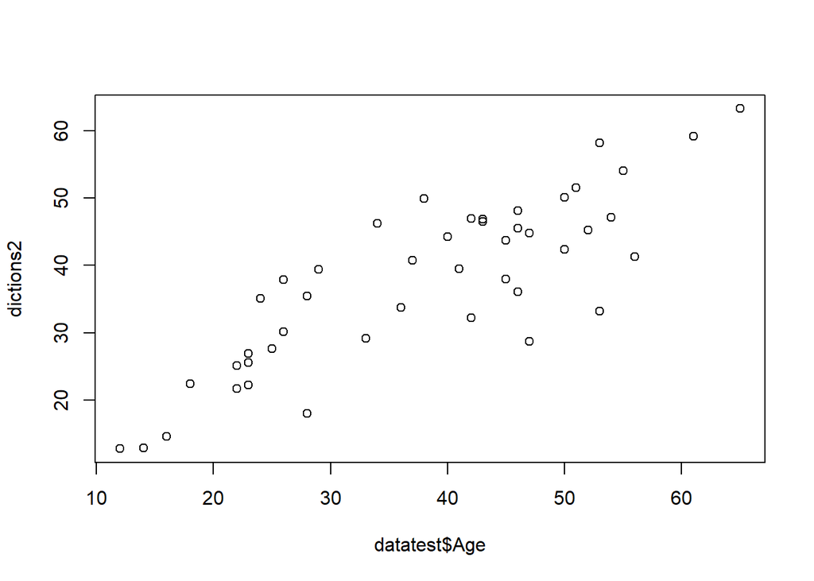

```r
plot(dictions2~datatest$Age)
```

Using cross-validation, the predictive performance of this model is not ideal. The RMSE is 7.351 and adjusted r2 = 0.53 when comparing testing data to model predictions.

Using k-fold cross-validation, we observed an RMSE 8.04 (+/- 1.2; +/- SE) and r2 of 0.66 (+/- 0.13; +/- SE).

For each 1 cm increase in body length, ponies are 1.03 months older.  
Male ponies are 6.5 months older than female ponies.  
For each 0.3 g increase in mass, we expect ponies to increase in age by 0.3.  
For each 1% increase in color saturation, we expect ponies to increase in age by 0.3.